# MATH_6395_Homework_2_Report

## MATH 6395: Homework #2 - Report (section: 3.2.1-3.2.3 from "Applied Stochastic Processes" by Mario LefeBvre) by Barry Daemi $$\newcommand{\C}{\mathbb{C}} \newcommand{\R}{\mathbb{R}} \newcommand{\Z}{\mathbb{Z}} \newcommand{\Q}{\mathbb{Q}} \newcommand{\P}{\mathbb{P}} \newcommand{\F}{\mathbb{F}} \newcommand{\N}{\mathbb{N}}$$

Suppose there exists a stochastic process $\{ X_{n}, n=0,1,\ldots \}$ and it *state space*, $ S_{X_{n}} = \{ \omega_{1},\ldots, \omega_{n} \} \subset \N$. By theorm, the integer set, $\N$, is countably infinite [[1](https://proofwiki.org/wiki/Integers_are_Countably_Infinite)], and by another theorem the subset of the *state space*, $\alpha = S_{X_{n}}$, is also countable [[2](https://proofwiki.org/wiki/Subset_of_Countably_Infinite_Set_is_Countable)], and thus finite. This is a similar construction to **Definition 3.2.1** from Mario Lefebvre (pg. 77-78, 2007):

> **Definition 3.2.1** A stochastic process $\{X_{n}, n=0,1,\ldots \}$ whose space $S_{X_{n}}$ is finite or countably infinite is **stationary** (or **time-homogeneous**) **Markov chain** if

> $$P[X_{n+1}=j | X_{n}=i, X_{n-1}=i_{n}-1,\ldots,X_{0}=i_{0}]= P[X_{X_{n+1}}=j | X_{n}=i]=p_{i,j}$$

> for all states $i_{0},\ldots,i_{n-1},i,j$ and for any $n \geq 0$.

In essence a *stochastic process* is a infinite set of independent and identically distributed random variables. The resulting sample value of each of the random variables is called the state of that random variable at the given $n$ step; e.g. the random variable in **Definition 3.2.1**, $X_{n}$ when sampled resulted in the state $i$, meaning that the process visited state $i$ at $n$ step. Consequentially each step of the discrete Markov process is a chance selection of a given random variable at a given time-step, e.g. $n=0,1,2,\ldots$.  
Concerning ourselves with the random variables themselves, and the process of which their states are assigned probability measures, one can expound that the illustration of higher dimensional random variables is intractable, and thus we choice to illustrate a random variable of three states.

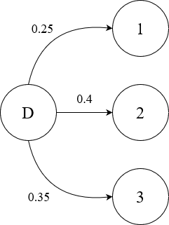

Figure 1: Simple illustration of Markov Chain at time-step $n$.

Given the illustration is a simple illustration of the $n$ step of some given Markov process, we can draw observations from it. One can observe that the future state of the process is denoted, $1,2,3$ in the illustration, and that each of these states possess an probability measure which reflects the likelihood of the process visiting that a given state at the given time-step, $n$.  
And we can simplify this diagram down to a row vector

|  | 1 | 2 | 3 |
| --- | --- | --- | --- |
| D | 0.25 | 0.40 | 0.35 |

So we can observe that the probability of the random variable $X_{n}$ is spread over its observed event set elements, e.g., $1,2,3$. However considering a continuous random variable makes the creation of this matrix intractable, as the probability measurement of each state in any given continuous random variable is approximately zero, as the probability mass is spread over the entire countably infinite states set. Otherwise for a discrete Markov process, one can construct this given vector with the finite probability measurements, and can extrapolate this process to each of the random variables of the Markov chain to creation a **transition probability matrix**. And simply each of the row of the **transition probability matrix** a random variable's distribution. A more formal description of a **transition probabilit matrix** is presented by **Definition 3.2.2**.

> $$P = \begin{bmatrix} p_{0,0} & p_{0,1} & p_{0,2} & \cdots \\p_{1,0} & p_{1,1} & p_{1,2} & \cdots \\ p_{2,0} & p_{2,1} & p_{2,2} & \cdots \\ \vdots & \vdots & \vdots & \ddots \end{bmatrix}$$

Though we forgot to mention something important the probability measuremeants for the Markov process are conditional probabilities, where the probability measurement is based on a pair events, i.e. if given state 1 then state 2 follows, then probability is $p_{1,2}$ from the **transition probability matrix**.  
The probability axioms still apply for stochastic process, and therefore each of the conditional probability measurements will be found in-between $0 \leq P(i,j) \leq 1$. And as such as each of the rows of the **transition probability matrix** represents the conditional probability distribution of an given random variable, so, each row must sum to $1$, otherwise the **transition probability matrix** contains an error, or is simply not valid.  
Anyhow, each time-step of the Markov chain possesses a **transition probability matrix**, i.e. $P^{(0)}$ is the initial **transition probability matrix** and $P^{(0)}$ is the $n$ time-step **transition probability matrix**. But how do we go from $P^{(0)} \to P^{(n)}$? By **Proposition 3.2.1 (Chapman-Kolmogorov equation)**, we can simply matrix-multiply the initial **transition probability matrix** $n$ times to calculate the $n$ time-step **transition probability matrix**, $p^{(n)}$. And in essence each time-step will result in an $+1$ increase in the initial **transition probability matrix** exponent power. Eventually as $n \to \infty$, or as $n$ become sufficiently large, the **transition probability matrix**, $P$, will tend to the stationary distribution. Though depending on the charactistic of the **transition probability matrix** the stationary distribution could be considered a limiting probability distribution, if each of the given states are reccurrent, as stated in **Proposition 3.2.6**; though if one or more of the states are transients, then the stationary distribution is not considered a limiting probability distribution as it is a periodic Markov chain.  
We think it best to provide the reader with an example, so to better demonstrate the mechanic behind the mathematical notation. So suppose there exists a stochastic process $\{ X_{i}, i=0,1,2 \} \}$ and its *state space*, $ S_{X_{n}} = \{ 0,1,2 \}$, and an initial **transition matrix**

$$P^{(0)} = \begin{bmatrix} 0.50 & 0.50 & 0 \\ 0 & 1 & 0 \\ 0.20 & 0.30 & 0.50 \end{bmatrix},$$

and an illustration of this example Markov chain is shown below.

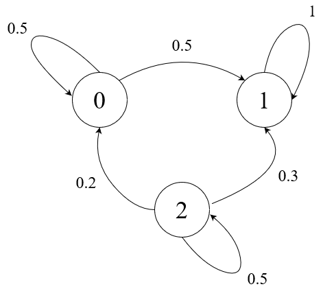

First time-step,

$$P^{(1)} = \begin{bmatrix} 0.25 & 0.75 & 0 \\ 0 & 1 & 0 \\ 0.20 & 0.55 & 0.0.25 \end{bmatrix} = \begin{bmatrix} 0.50 & 0.50 & 0 \\ 0 & 1 & 0 \\ 0.20 & 0.30 & 0.50 \end{bmatrix}*\begin{bmatrix} 0.50 & 0.50 & 0 \\ 0 & 1 & 0 \\ 0.20 & 0.30 & 0.50 \end{bmatrix}.$$

Second time-step,

$$P^{(2)} = \begin{bmatrix} 0.125 & 0.875 & 0 \\ 0 & 1 & 0 \\ 0.15 & 0.725 & 0.0.125 \end{bmatrix} = \begin{bmatrix} 0.50 & 0.50 & 0 \\ 0 & 1 & 0 \\ 0.20 & 0.30 & 0.50 \end{bmatrix}*\begin{bmatrix} 0.50 & 0.50 & 0 \\ 0 & 1 & 0 \\ 0.20 & 0.30 & 0.50 \end{bmatrix}*\begin{bmatrix} 0.50 & 0.50 & 0 \\ 0 & 1 & 0 \\ 0.20 & 0.30 & 0.50 \end{bmatrix}.$$

Third time-step,

$$P^{(3)} = \begin{bmatrix} 0.0625 & 0.9375 & 0 \\ 0 & 1 & 0 \\ 0.100 & 0.0.8375 & 0.0.0625 \end{bmatrix} = \begin{bmatrix} 0.50 & 0.50 & 0 \\ 0 & 1 & 0 \\ 0.20 & 0.30 & 0.50 \end{bmatrix}*\begin{bmatrix} 0.50 & 0.50 & 0 \\ 0 & 1 & 0 \\ 0.20 & 0.30 & 0.50 \end{bmatrix}*\begin{bmatrix} 0.50 & 0.50 & 0 \\ 0 & 1 & 0 \\ 0.20 & 0.30 & 0.50 \end{bmatrix}*\begin{bmatrix} 0.50 & 0.50 & 0 \\ 0 & 1 & 0 \\ 0.20 & 0.30 & 0.50 \end{bmatrix}.$$

Finally lets skip to the $n$ time-step,

$$P^{(\infty)} = \lim_{i \to \infty} P^{(i)}= \begin{bmatrix} 0 & 1 & 0 \\ 0 & 1 & 0 \\ 0 & 1 & 0 \end{bmatrix}$$

### References:

1. [0]: Lefebvre, Mario. Applied Stochastic Processes. Springer, 2007.
2. [1]: Integers are Countably Infinite. Proof Wiki, https://proofwiki.org/wiki/Integers_are_Countably_Infinite
3. [2]:Subset of Countably Infinite Set is Countable. Proof Wiki, https://proofwiki.org/wiki/Subset_of_Countably_Infinite_Set_is_Countable